[GitHub](https://github.com/JuliaGeometry/DelaunayTriangulation.jl)[](https://github.com/JuliaGeometry/DelaunayTriangulation.jl/tree/main/docs/src/literate_tutorials/operations_split_triangle.jl)

# Triangulation Operations

## Triangle Splitting

As we briefly discussed in the `legalise_edge!` tutorial, it is sometimes useful to put a point inside of an existing triangle, and then to connect all the vertices of that triangle to that new point, thereby splitting that triangle into three new triangles. This is called *triangle splitting*.

Let us give an example.

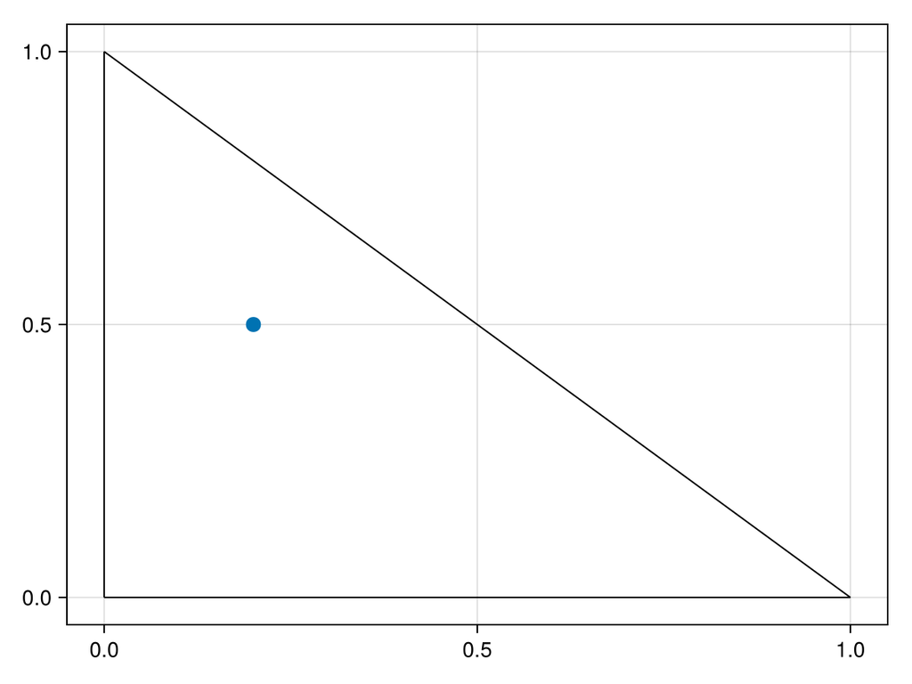

```julia
using DelaunayTriangulation
using CairoMakie

points = [(0.0, 0.0), (1.0, 0.0), (0.0, 1.0)]
p = (0.2, 0.5)
tri = triangulate(points)
fig, ax, sc = triplot(tri)
scatter!(ax, [p], markersize=14)
fig
```

The blue point shows the point we want to add into the triangulation using `split_triangle!`. To use this, we provide (1) the index of the point in `points` and (2) the triangle that the point is in. The index of the point will be `4` after pushing `p` into `points`, and in this simple example the triangle that `p` is in is `(1, 2, 3)`.

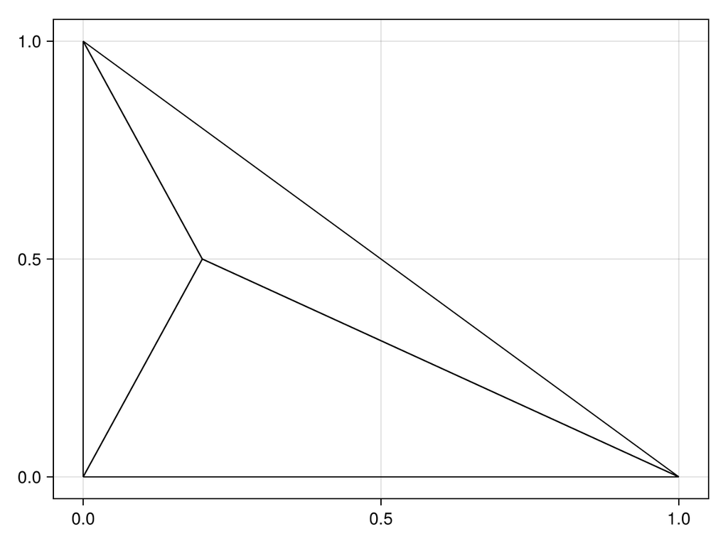

```julia
push!(points, p)
r = length(points)
i, j, k = 1, 2, 3
split_triangle!(tri, i, j, k, r)
fig, ax, sc = triplot(tri)
fig
```

See the `legalise_edge!` tutorial for more discussion about restoring the Delaunay property of the triangulation after using `split_triangle!`.

## Just the code

An uncommented version of this example is given below. You can view the source code for this file [here](https://github.com/JuliaGeometry/DelaunayTriangulation.jl/tree/main/docs/src/literate_tutorials/operations_split_triangle.jl).

```julia
using DelaunayTriangulation
using CairoMakie

points = [(0.0, 0.0), (1.0, 0.0), (0.0, 1.0)]
p = (0.2, 0.5)
tri = triangulate(points)
fig, ax, sc = triplot(tri)
scatter!(ax, [p], markersize=14)
fig

push!(points, p)
r = length(points)
i, j, k = 1, 2, 3
split_triangle!(tri, i, j, k, r)
fig, ax, sc = triplot(tri)
fig
```

*This page was generated using Literate.jl.*